**POLS/CSSS 503, University of Washington, Spring 2015**

# POLS/CSSS 503: Problem Set 1 Solutions

Jeffrey B. Arnold

April 16, 2015

Source the libraries that will be used

```r
library("ggplot2")
library("dplyr")
library("readr")
library("knitr")
theme_local <- theme_minimal
# nicer default binwidths
sturges_binwidth <- function(x) {
  diff(range(x)) / nclass.Sturges(x)
}
```

## Problem 1

### part a

```r
democracy <- read.csv(file = "http://pols503.github.io/pols_503_sp15/data/democracy.csv", na = ".", stringsAsFactors = FALSE)
```

### part b

Summarize the dataset using summary

```r
summary(democracy)
```

```
##     COUNTRY         CTYNAME             REGION               YEAR
##  Min.   :  1.00   Length:4126        Length:4126        Min.   :1951
##  1st Qu.: 39.00   Class :character   Class :character   1st Qu.:1965
##  Median : 71.00   Mode  :character   Mode  :character   Median :1974
##  Mean   : 70.18                                         Mean   :1973
##  3rd Qu.:103.00                                         3rd Qu.:1983
##  Max.   :135.00                                         Max.   :1990
##
##     BRITCOL            CATH           CIVLIB           EDT
##  Min.   :0.0000   Min.   : 0.00   Min.   :1.000   Min.   : 0.030
##  1st Qu.:0.0000   1st Qu.: 0.00   1st Qu.:2.000   1st Qu.: 2.214
##  Median :0.0000   Median :22.25   Median :5.000   Median : 4.540
##  Mean   :0.2433   Mean   :37.20   Mean   :4.076   Mean   : 4.853
##  3rd Qu.:0.0000   3rd Qu.:84.00   3rd Qu.:6.000   3rd Qu.: 7.085
##  Max.   :1.0000   Max.   :99.00   Max.   :7.000   Max.   :12.810
##                                   NA's   :1727    NA's   :1226
##      ELF60             GDPW           MOSLEM           NEWC
##  Min.   :0.0000   Min.   :  480   Min.   : 0.00   Min.   :0.0000
##  1st Qu.:0.1000   1st Qu.: 2458   1st Qu.: 0.00   1st Qu.:0.0000
##  Median :0.3700   Median : 6012   Median : 0.50   Median :0.0000
##  Mean   :0.3995   Mean   : 8877   Mean   :19.74   Mean   :0.4561
##  3rd Qu.:0.6900   3rd Qu.:12608   3rd Qu.:16.20   3rd Qu.:1.0000
##  Max.   :0.9300   Max.   :37903   Max.   :99.90   Max.   :1.0000
##  NA's   :542
##       OIL             POLLIB          REG              STRA
##  Min.   :0.0000   Min.   :1.00   Min.   :0.0000   Min.   :0.0000
##  1st Qu.:0.0000   1st Qu.:2.00   1st Qu.:0.0000   1st Qu.:0.0000
##  Median :0.0000   Median :3.00   Median :0.0000   Median :0.0000
##  Mean   :0.1001   Mean   :3.86   Mean   :0.3987   Mean   :0.3752
##  3rd Qu.:0.0000   3rd Qu.:6.00   3rd Qu.:1.0000   3rd Qu.:1.0000
##  Max.   :1.0000   Max.   :7.00   Max.   :1.0000   Max.   :5.0000
##                   NA's   :1727
```

### part c

Use `select` to remove the identifier variables, and then compute the correlation of the remaining variables with the `cor` function. The argument `use` handles how missing values in `cor` are treated. The options `"complete.obs"` will drop any case (row) with a missing value, while `"pairwise.complete.obs"` will drop pairs will missing values.

```r
democracy %>%
  select(- COUNTRY, - CTYNAME, - REGION, - YEAR) %>%
  cor(use = "pairwise.complete.obs")
```

```
##             BRITCOL        CATH      CIVLIB         EDT       ELF60
## BRITCOL  1.00000000 -0.28009968 -0.04963425 -0.09235194  0.20155513
## CATH    -0.28009968  1.00000000 -0.22406812  0.14097672 -0.31366098
## CIVLIB  -0.04963425 -0.22406812  1.00000000 -0.63603368  0.41088682
## EDT     -0.09235194  0.14097672 -0.63603368  1.00000000 -0.40866610
## ELF60    0.20155513 -0.31366098  0.41088682 -0.40866610  1.00000000
## GDPW    -0.15918106  0.15860000 -0.67084923  0.74244408 -0.36605673
## MOSLEM   0.09528997 -0.50302945  0.34297500 -0.45096636  0.17665584
## NEWC     0.48995059 -0.45410908  0.37137066 -0.44127106  0.48234363
## OIL     -0.01222767  0.04335695  0.11174668 -0.17770152  0.18390644
## POLLIB   0.07771100  0.19721940 -0.91714293  0.63532268 -0.40327093
## REG     -0.03493746  0.21330432 -0.80634822  0.57880681 -0.37551629
## STRA    -0.12601072  0.35546736 -0.03826983  0.05403654 -0.09294666
##                GDPW      MOSLEM        NEWC          OIL      POLLIB
## BRITCOL -0.15918106  0.09528997  0.48995059 -0.012227667  0.07771100
## CATH     0.15860000 -0.50302945 -0.45410908  0.043356953  0.19721940
## CIVLIB  -0.67084923  0.34297500  0.37137066  0.111746676 -0.91714293
## EDT      0.74244408 -0.45096636 -0.44127106 -0.177701525  0.63532268
## ELF60   -0.36605673  0.17665584  0.48234363  0.183906439 -0.40327093
## GDPW     1.00000000 -0.25473954 -0.47355229  0.067272637  0.66035421
## MOSLEM  -0.25473954  1.00000000  0.38301942  0.148945598 -0.30646515
## NEWC    -0.47355229  0.38301942  1.00000000  0.057747674 -0.34310239
## OIL      0.06727264  0.14894560  0.05774767  1.000000000 -0.10535464
## POLLIB   0.66035421 -0.30646515 -0.34310239 -0.105354637  1.00000000
## REG      0.57672403 -0.34690353 -0.36705770 -0.111589678  0.84194283
## STRA     0.01197220 -0.12683043 -0.22460005  0.004686631  0.01615198
##                 REG         STRA
## BRITCOL -0.03493746 -0.126010725
## CATH     0.21330432  0.355467362
## CIVLIB  -0.80634822 -0.038269826
## EDT      0.57880681  0.054036539
## ELF60   -0.37551629 -0.092946665
## GDPW     0.57672403  0.011972203
## MOSLEM  -0.34690353 -0.126830426
## NEWC    -0.36705770 -0.224600051
## OIL     -0.11158968  0.004686631
## POLLIB   0.84194283  0.016151982
## REG      1.00000000  0.058042473
## STRA     0.05804247  1.000000000
```

### part d

To plot a histogram with each value of `POLLIB` in its own bin, either adjust the `binwidth` parameter of `geom_histogram`

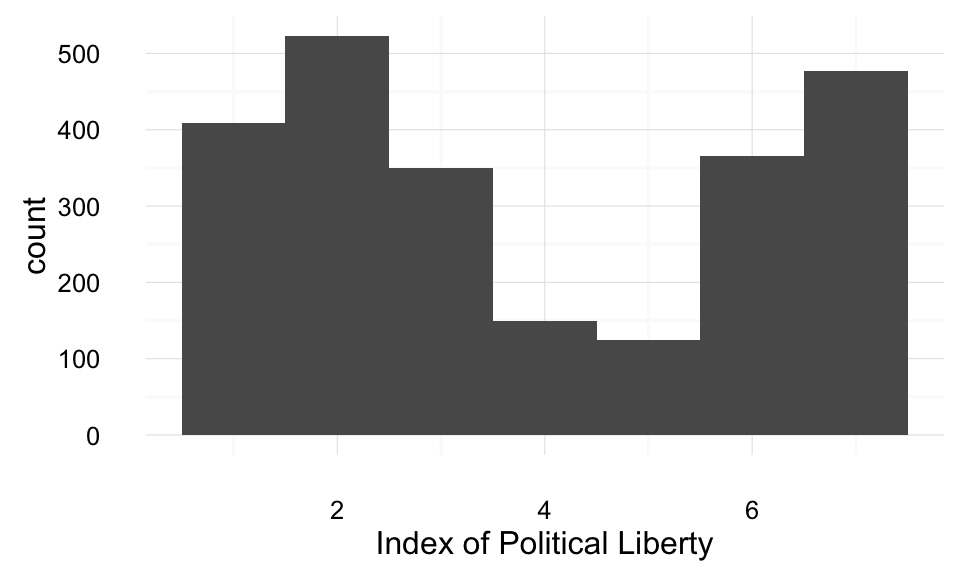

```r
ggplot(democracy, aes(x = POLLIB)) +
  geom_histogram(binwidth = 1) +
  xlab("Index of Political Liberty") +
  theme_local()
```

or turn `POLLIB` into a factor

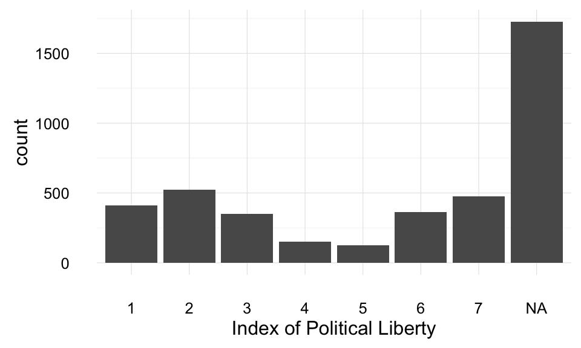

```r
ggplot(democracy, aes(x = factor(POLLIB))) +
  geom_bar() +
  xlab("Index of Political Liberty") +
  theme_local()
```

### part e

A histogram of GDP per capita is

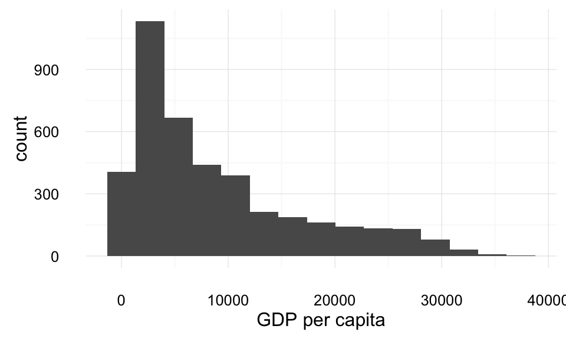

```r
ggplot(democracy, aes(x = GDPW)) +
  geom_histogram(binwidth = sturges_binwidth(democracy$GDPW)) +
  xlab("GDP per capita") +
  theme_local()
```

### part f

A histogram of *log* GDP per capita is

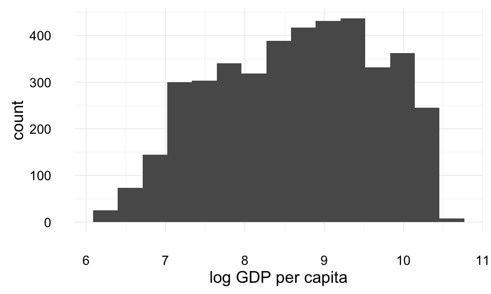

```r
ggplot(democracy, aes(x = log(GDPW))) +
geom_histogram(binwidth = sturges_binwidth(log(democracy$GDPW))) +
xlab("log GDP per capita") +
theme_local()
```

### part g

Create a scatterplot of political liberties against GDP per capita

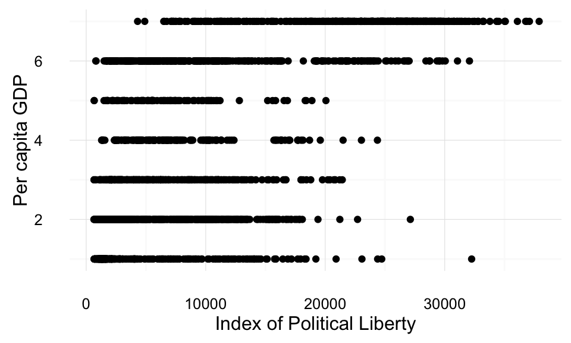

```r
ggplot(democracy, aes(x = GDPW, y = POLLIB)) +
  geom_point() +
  ylab("Per capita GDP") +
  xlab("Index of Political Liberty") +
  theme_local()
```

### part h

Create the same scatterplot while jittering the points

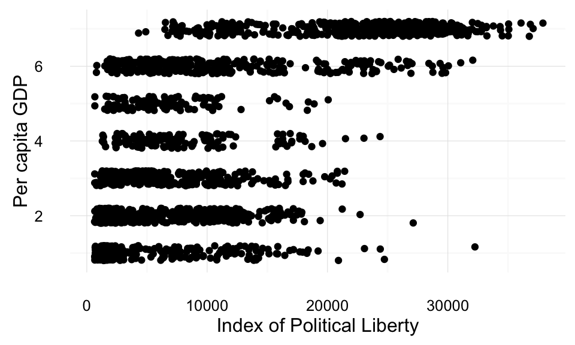

```r
ggplot(democracy, aes(x = GDPW, y = POLLIB)) +
  geom_jitter(height = 0.5) +
  scale_y_continuous("Per capita GDP") +
  scale_x_continuous("Index of Political Liberty") +
  theme_local()
```

### part i

Create a scatterplot of political liberties against *log* GDP per capita

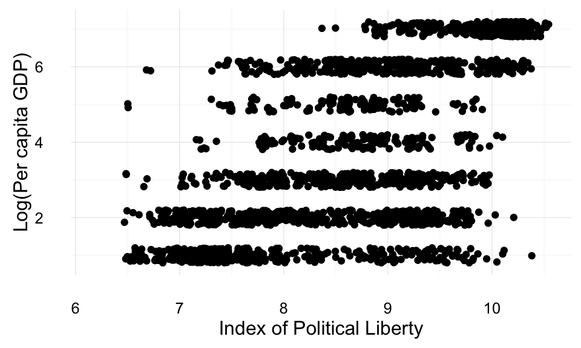

```r
ggplot(democracy, aes(x = log(GDPW), y = POLLIB)) +
  geom_jitter(height = 0.5) +
  scale_y_continuous("Log(Per capita GDP)") +
  scale_x_continuous("Index of Political Liberty") +
  theme_local()
```

### part j

A boxplot of GDP per capita for oil producing and non-oil producing nations is

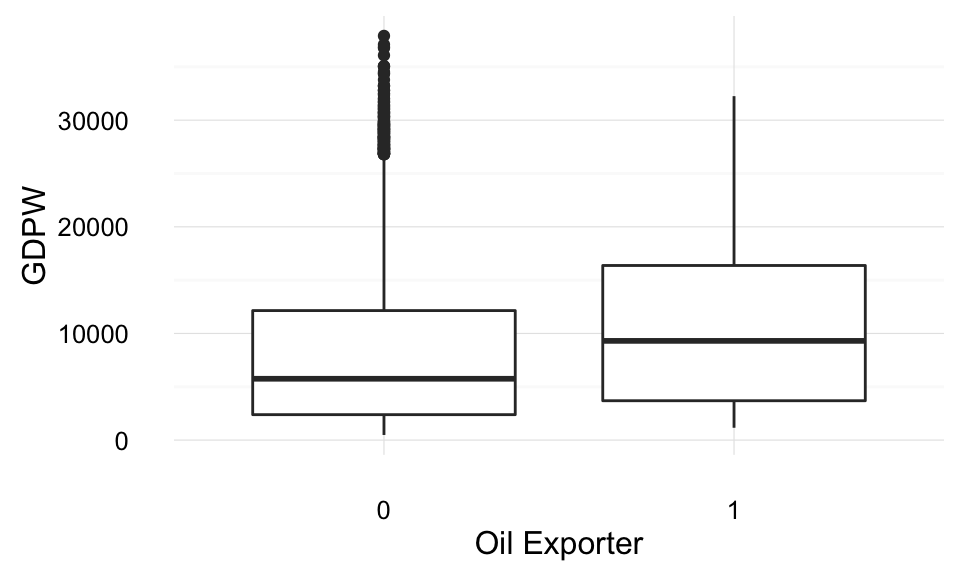

```r
ggplot(democracy, aes(x = factor(OIL), y = GDPW)) +
  geom_boxplot() +
  scale_x_discrete("Oil Exporter") +
  theme_local()
```

### part k

```r
catholic_gdpw <- filter(democracy, CATH > 40)$GDPW %>% mean(na.rm = TRUE)
catholic_gdpw
```

```
## [1] 10295.13
```

```r
all_gdpw <- mean(democracy$GDPW, na.rm = FALSE)
all_gdpw
```

```
## [1] 8876.959
```

```r
catholic_gdpw / all_gdpw
```

```
## [1] 1.159758
```

### part l

The GDP per capita in countries with greater than 60% ethnolinguistic fractionalization, less than 60%, and missing ethnolinguistic fractionalization is shown in the following table:

```r
elf_summary <- democracy %>%
  mutate(high_elf60 = ELF60 > 0.6) %>%
  group_by(high_elf60) %>%
  summarise(gdpw_mean = mean(GDPW))
kable(elf_summary)
```

| high_elf60 | gdpw_mean |
| --- | --- |
| FALSE | 11803.780 |
| TRUE | 3590.939 |
| NA | 7767.245 |

### part m

The median years of education for all countries in 1985 was 5.6 years.

```r
democracy %>%
  filter(YEAR == 1985) %>%
  summarise(EDT = median(EDT, na.rm = TRUE)) %>%
  select(EDT)
```

```
##     EDT
## 1 5.625
```

### part n

Venezuela was the country closest (in this case, equal) to the median of the average years of education in 1985.

```r
democracy %>%
  filter(YEAR == 1985, ! is.na(EDT)) %>%
  mutate(med_edt_diff = abs(EDT - median(EDT))) %>%
  filter(med_edt_diff == min(med_edt_diff)) %>%
  select(CTYNAME, EDT)
```

```
##     CTYNAME   EDT
## 1 Venezuela 5.625
```

### part o

The median of the average years of education for democracies in 1985 was 7.8 years.

```r
edt_reg_1985 <-
  democracy %>%
  filter(! is.na(EDT),
         ! is.na(REG),
         as.logical(REG),
         YEAR == 1985)

edt_reg_1985$EDT %>% median()
```

```
## [1] 7.805
```

### part p

Mauritius was democracy that were closest to the median of the average years of education for all democracies in 1985

```r
edt_reg_1985 %>%
  mutate(med_edt_diff = abs(EDT - median(EDT))) %>%
  filter(med_edt_diff == min(med_edt_diff)) %>%
  select(CTYNAME, EDT)
```

```
##     CTYNAME   EDT
## 1 Mauritius 7.805
```

### part q

The 25th and 75th percentiles of the ethnolinguist fractionalization (`ELF60`) for new and old countries (`NEWC`) is shown in the table below:

```r
dem_elf_tabl <-
democracy %>%
  filter(! is.na(ELF60)) %>%
  mutate(`Country Type` = ifelse(as.logical(NEWC), "new", "old")) %>%
  group_by(`Country Type`) %>%
  summarise(elf60_p25 = quantile(ELF60, probs = 0.25),
            elf60_p75 = quantile(ELF60, probs = 0.75))
kable(dem_elf_tabl)
```

| Country Type | elf60_p25 | elf60_p75 |
| --- | --- | --- |
| new | 0.42 | 0.75 |
| old | 0.06 | 0.44 |

## Problem 2

Answers will vary. Obviously.

This work is licensed under a [Creative Commons Attribution-NonCommercial-ShareAlike 4.0 International License](http://creativecommons.org/licenses/by-nc-sa/4.0/). R code is licensed under a [BSD 2-clause](http://www.r-project.org/Licenses/BSD_2_clause) license.